# POLS 2072Q

Lecture 3 | Observations and Variables

## Today’s Question

If X = {78, 80, 60}, then X is:

1. A character variable
2. A binary variable
3. A non-binary variable
4. An observation

## Plan for Today

- What are data / datasets?
  - What is an observation?
  - What is a variable?
- Types of variables based on content
  - character vs. numeric variables
  - binary vs. non-binary variables

## What are Data / Datasets?

- Datasets capture the characteristics of a particular set of individuals or entities:
  - students, classrooms, schools, …
- Datasets are typically organized as data frames where rows are observations and columns are variables

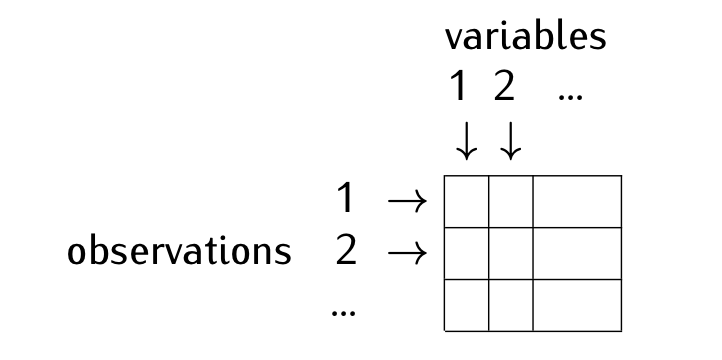

## Example of a Dataframe

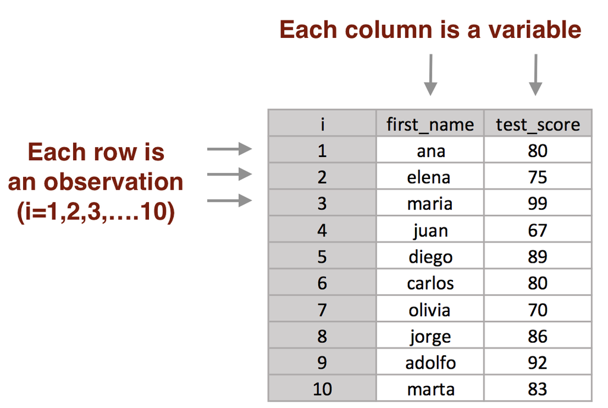

## What is an Observation?

- It is the information collected from a particular entity or individual in the study
- The unit of observation of the dataset defines the individuals or the entities that each observation in the dataframe represents
  - If unit of observation is students, each row in the dataframe represents a different student
- We usually refer to an observation by the row number in the dataframe, which we denote as *i*
  - What is the first observation (i=1) in the dataframe above?

## What is a Variable?

- A variable contains the values of a changing characteristic for the various individuals or entities in the study
- Every column of data in a dataframe is a variable
  - If unit of observation is students, each variable captures a specific characteristic of the students, for all the students in the study
- We usually refer to a variable by its name
  - *first_name, test_scores*

## Notation

- On the left-hand side of the equal sign, we identify the name of the variable
- On the right-hand side of the equal sign and inside curly brackets, we have the content of the variable: multiple observations, separated by commas

## Notation

- To represent each individual observation we use \(X_i\)
  - Where *i* stands for the observation number
  - The subscript *i* means that we have a different value of *X* for each value of *i*
- The total number of observations is denoted as *n*

## Types of Variables Based on Content

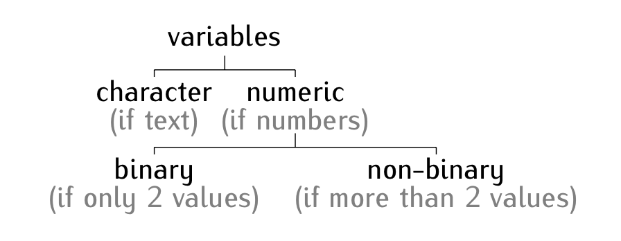

## Character vs. Numeric

- Character Variables contain text
  - *first_names* = {ana, elena, maria, …}
- Numeric Variables contain numbers
  - *test_scores* = {80, 75, 99, …}

## Numeric: Binary Variables

- Binary variables can take only two values:
  - 1s and 0s
- They represent the presence/absence of a trait:
  - 1 if individual *i* has the trait
  - 0 if individual *i* does not have the trait
- Example: *voted* = {1, 0, 0, 1, 1, 1, 0}

where

\(voted_i = \left\{\begin{matrix} 1 \ if \ voted \\ 0 \ if \ didn't \ vote \end{matrix}\right.\)

- Can you think of another example?

## Numeric: Non-binary Variables

- Non-binary variables can take more than two values
  - *distance* = {1.452, 2.345, 0.298}
  - *dice_roll* = {2, 4, 6}